# AMAP: Assisted Microbial Annotation Pipeline Report

#### F

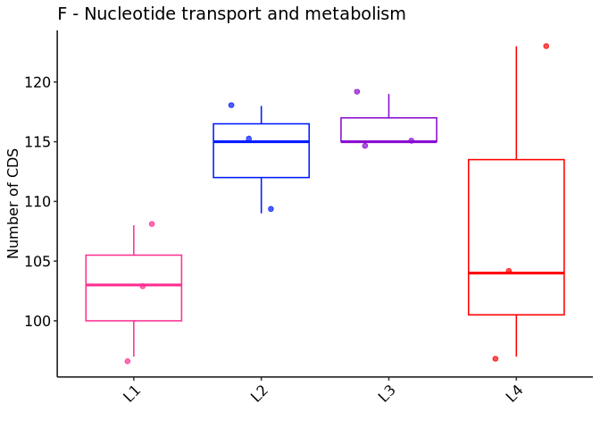

#### G

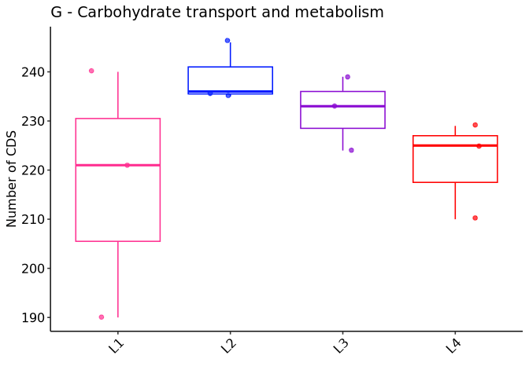

#### H

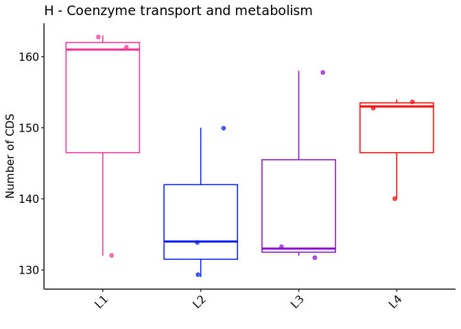

#### I

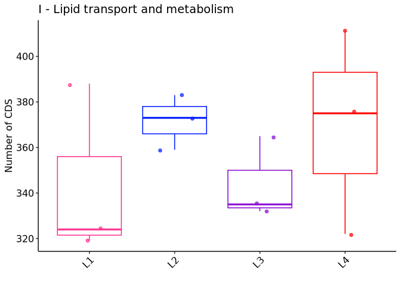

#### J

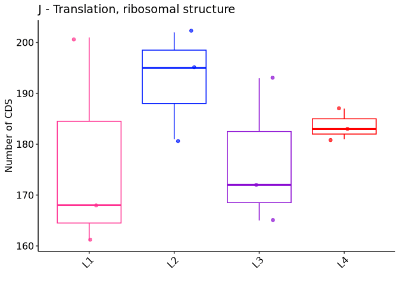

#### K

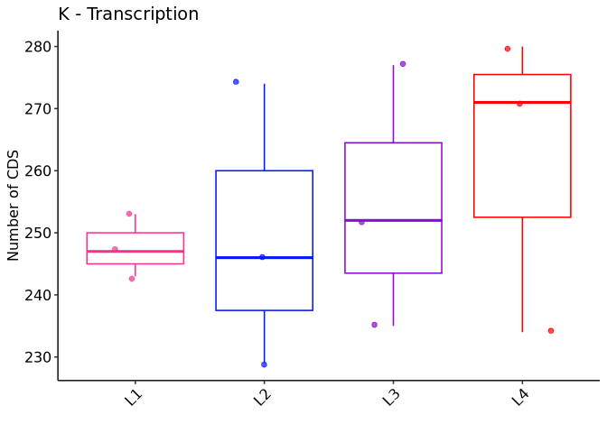

#### L

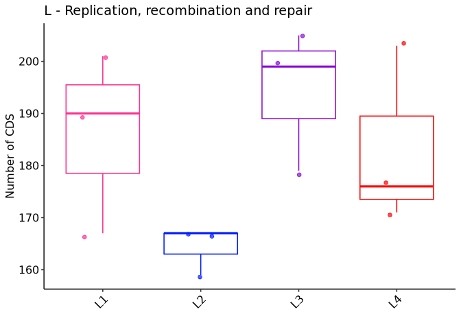

#### M

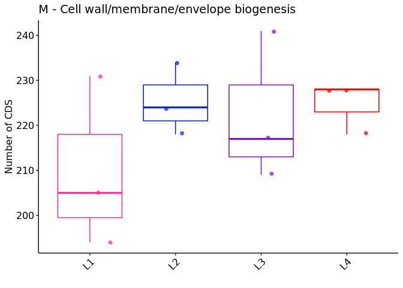

#### N

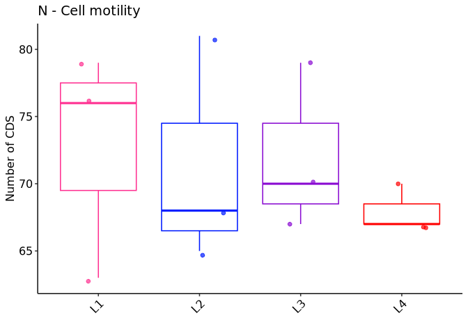

#### O

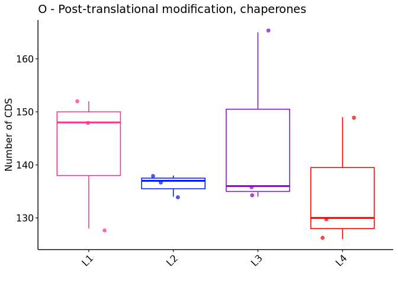

#### P

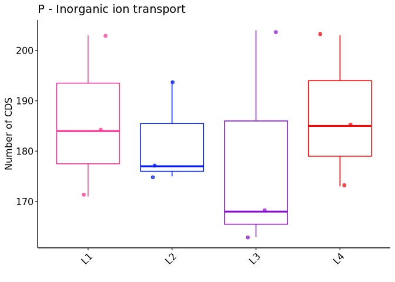

#### Q

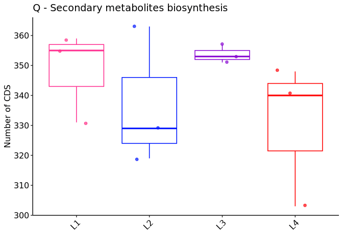

#### R

[figure not shown]

#### S

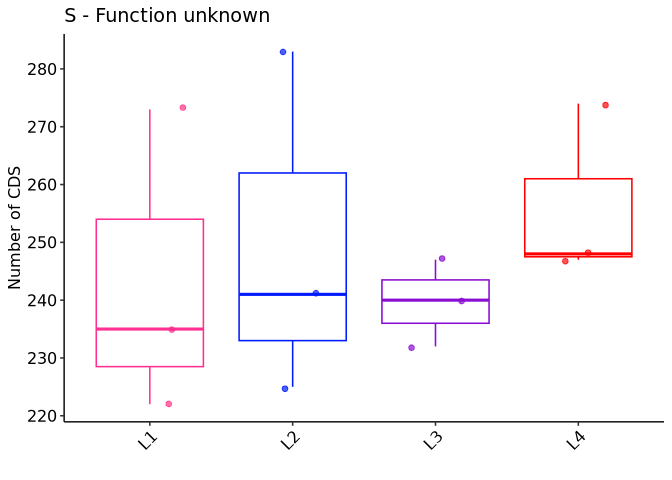

#### T

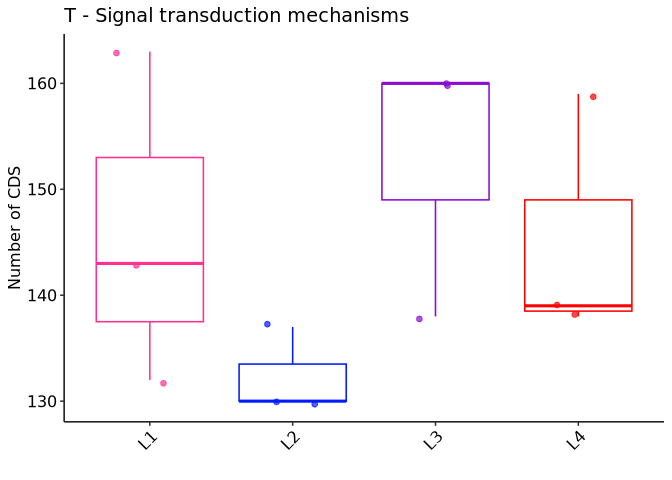

#### U

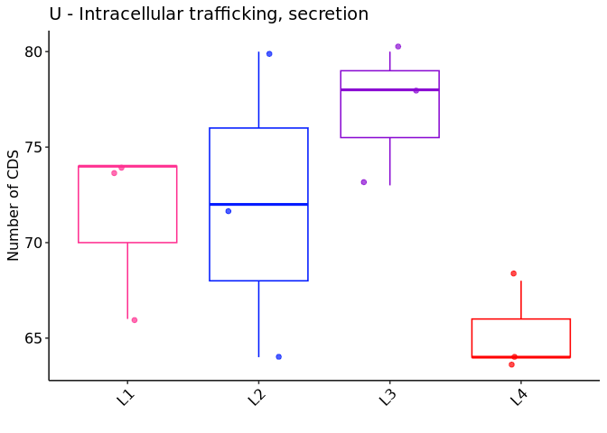

#### V

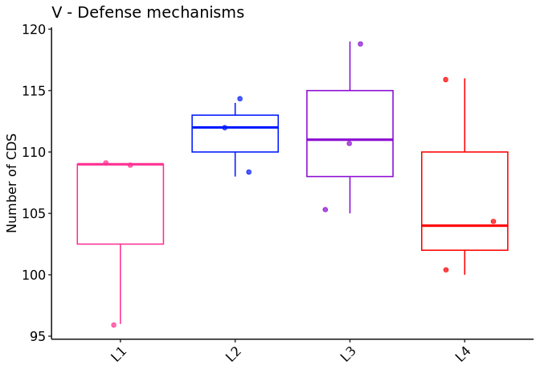

#### W

[figure not shown]

#### X

[figure not shown]

#### Y

[figure not shown]

#### Z

[figure not shown]

#### NA

[figure not shown]

## Mycobrowser Categories

*Mycobrowser functional categories are specific to the M. tuberculosis complex. This section is only shown when Mycobrowser data is available.*

### Overview

[interactive chart not shown]

### Per Category (%)

#### cell wall and cell processes

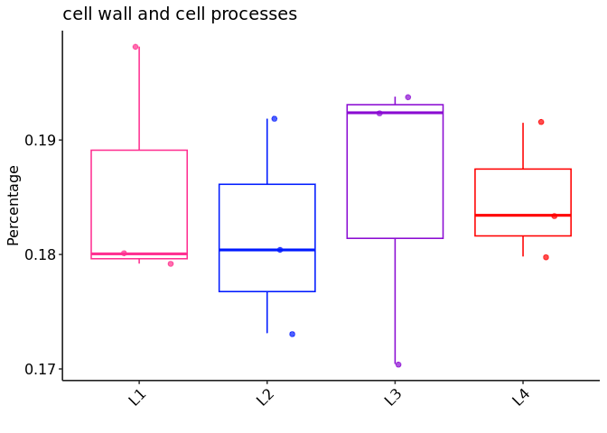

#### conserved hypotheticals

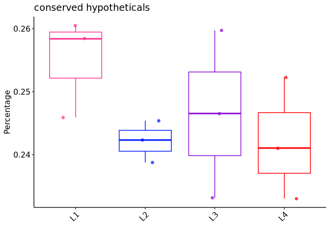

#### information pathways

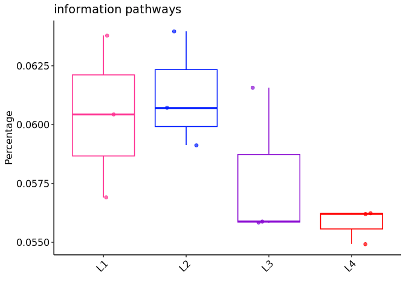

#### insertion seqs and phages

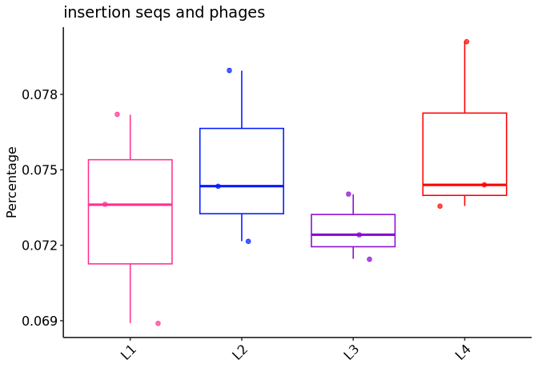

#### intermediary metabolism and respiration

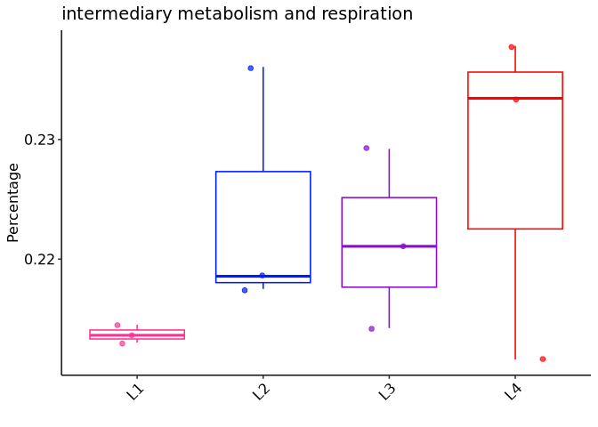

#### lipid metabolism

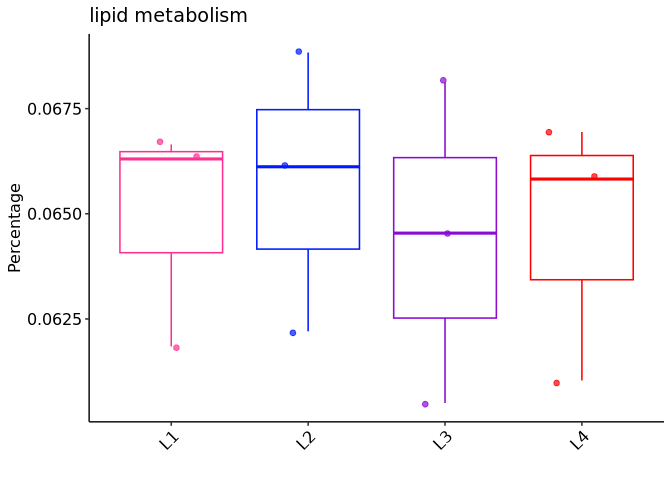

#### PE/PPE

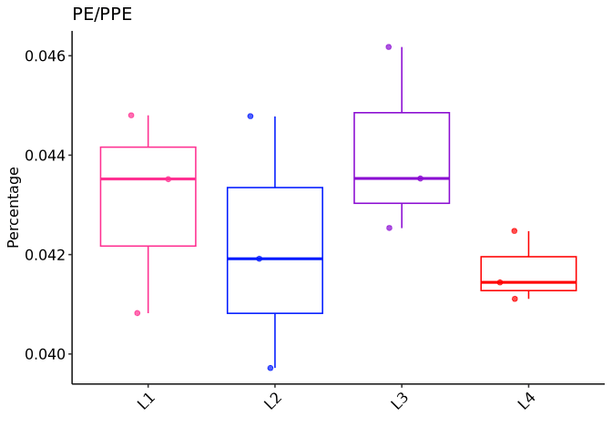

#### regulatory proteins

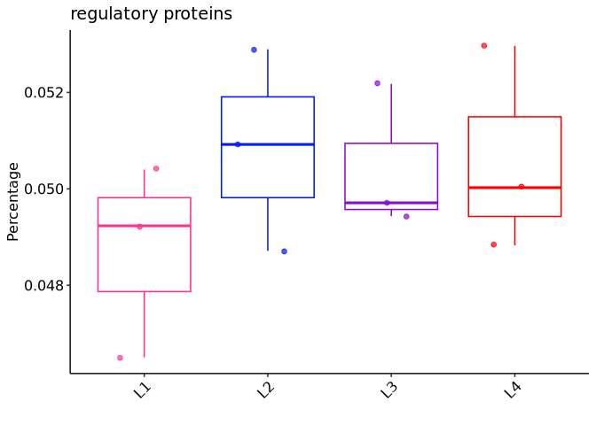

#### virulence, detoxification, adaptation

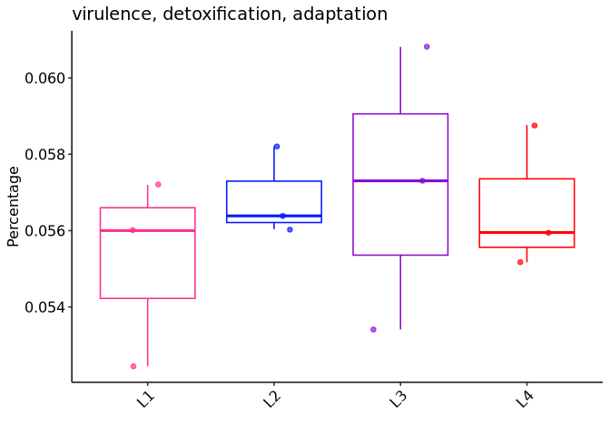

### Per Category (Nº CDS)

#### cell wall and cell processes

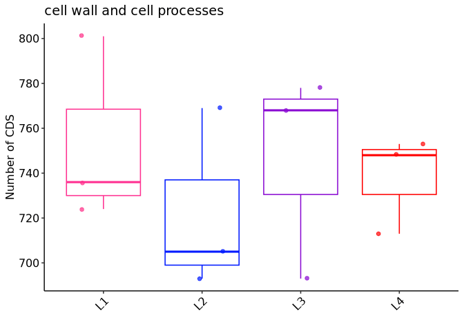

#### conserved hypotheticals

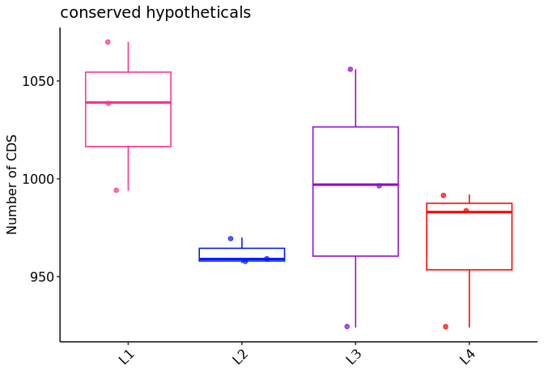

#### information pathways

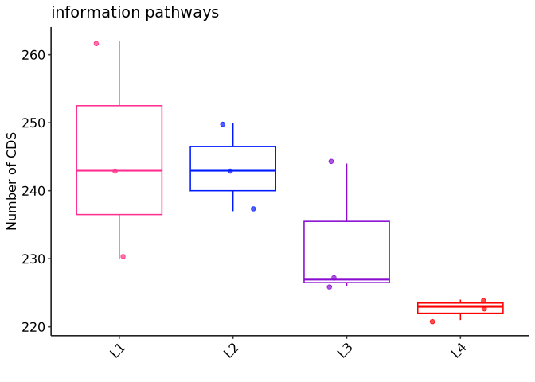

#### insertion seqs and phages

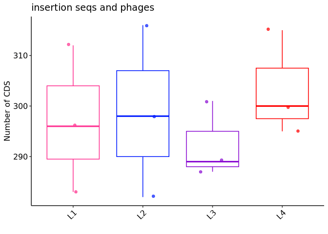

#### intermediary metabolism and respiration

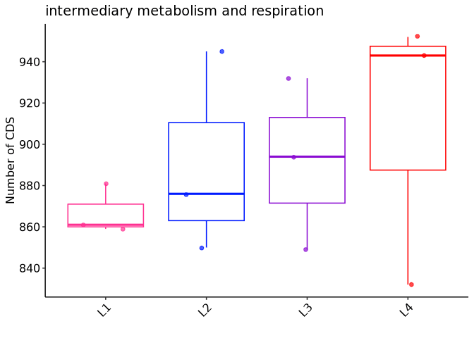

#### lipid metabolism

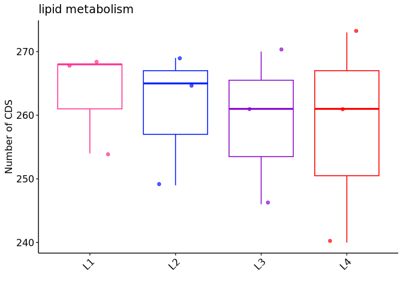

#### PE/PPE

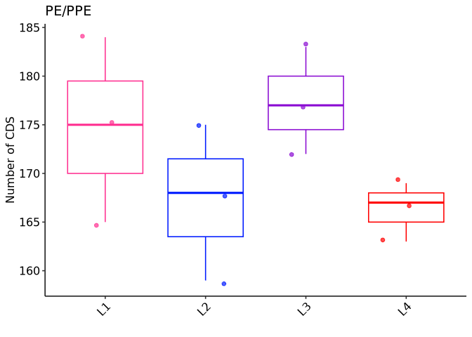

#### regulatory proteins

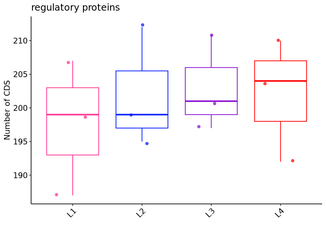

#### virulence, detoxification, adaptation

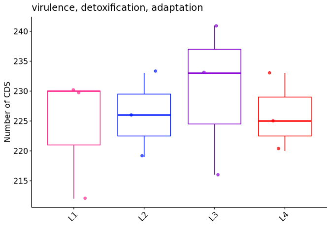

### Statistics

| Lineages | Functional_Category | Count | Mean_Pct | SD_Pct |
| --- | --- | --- | --- | --- |
| L1 | PE/PPE | 3 | 0.043 | 0.002 |
| L1 | cell wall and cell processes | 3 | 0.1858 | 0.0107 |
| L1 | conserved hypotheticals | 3 | 0.2549 | 0.0079 |
| L1 | information pathways | 3 | 0.0604 | 0.0034 |
| L1 | insertion seqs and phages | 3 | 0.0732 | 0.0042 |
| L1 | intermediary metabolism and respiration | 3 | 0.2137 | 0.0008 |
| L1 | lipid metabolism | 3 | 0.0649 | 0.0027 |
| L1 | regulatory proteins | 3 | 0.0487 | 0.002 |
| L1 | virulence, detoxification, adaptation | 3 | 0.0552 | 0.0025 |
| L2 | PE/PPE | 3 | 0.0421 | 0.0025 |

[output cut: 26 more lines]